# Homework 5

**Due Date:** 2024-11-20 at 8:30 AM PT

**Name:** Aaron Presser

## Preparation

1. We’re using the same [data file](https://github.com/gabehassler/PRGS-Intro-to-ML-2024/blob/main/data/processed/svi_covid.csv) from GitHub as the last assignment. If should be in the *data/processed* folder.

## Homework - Neural Newtorks

1. Use a simple neural network to predict the number of per-capita COVID-19 deaths in each county in the US using the SVI variables. The outcome variable is `total_deaths_per_100k` and the predictor variables are `EP_POV150, EP_UNEMP, EP_HBURD, EP_NOHSDP, EP_UNINSUR, EP_AGE65, EP_AGE17, EP_DISABL, EP_SNGPNT, EP_LIMENG, EP_MINRTY, EP_MUNIT, EP_MOBILE, EP_CROWD, EP_NOVEH, EP_GROUPQ, EP_NOINT`. The neural network should have one hidden layer with 10 nodes and use the ReLU activation function. Plot the predicted values against the true values. What is the mean squared error of the predictions in the test set?

```
Using cpu device
Mean Squared Error on the test set: 35996.0410
```

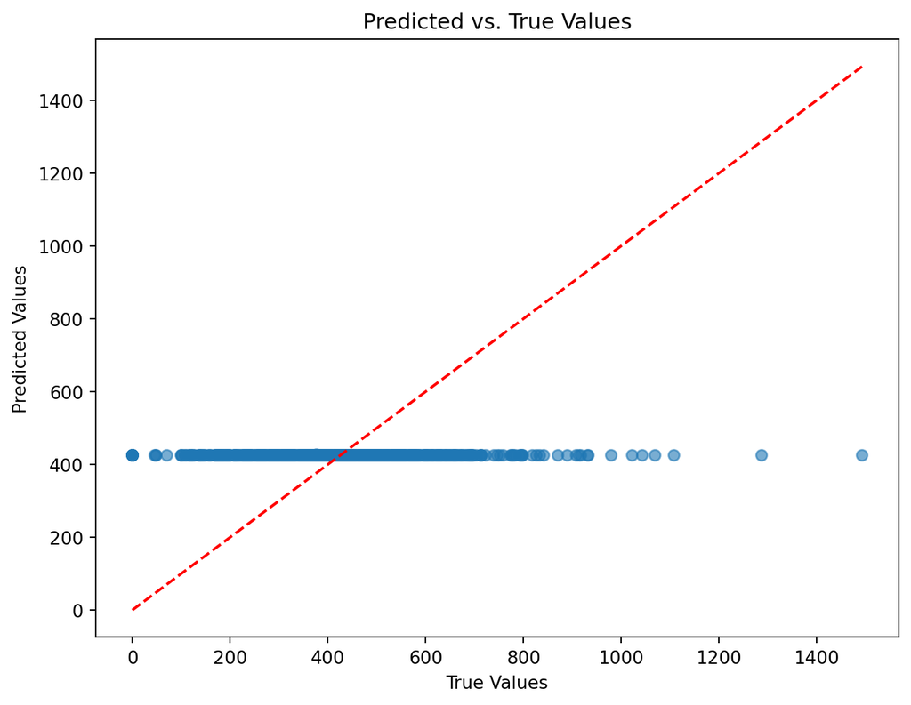

```python
import numpy as np
import pandas as pd
import matplotlib.pyplot as plt

import torch
from torch import nn
from torch.utils.data import random_split
from torch.utils.data import DataLoader, Dataset

from sklearn.metrics import mean_squared_error

torch.manual_seed(123)


df = pd.read_csv(r"C:\Users\apresser\code\PRGS-Intro-to-Machine-Learning\data\processed\svi_covid.csv")


# I asked ChatGPT for guidance on creating a simple neural network using the provided predictor and outcome variables. I specified that the network should include one hidden layer with 10 nodes and use the ReLU activation function. ChatGPT also walked me through how to adapt the example code for this specific assignment.

# Define the predictor and outcome columns
predictor_columns = ["EP_POV150", "EP_UNEMP", "EP_HBURD", "EP_NOHSDP", "EP_UNINSUR",
                     "EP_AGE65", "EP_AGE17", "EP_DISABL", "EP_SNGPNT", "EP_LIMENG",
                     "EP_MINRTY", "EP_MUNIT", "EP_MOBILE", "EP_CROWD", "EP_NOVEH",
                     "EP_GROUPQ", "EP_NOINT"]
outcome_column = "total_deaths_per_100k"

# Define a Dataset Class
class PandasDataset(Dataset):
    def __init__(self, dataframe, predictors, outcome):
        x = np.array(dataframe[predictors].values).reshape(-1, len(predictors))
        y = np.array(dataframe[outcome].values).reshape(-1, 1)
        self.x = torch.tensor(x, dtype=torch.float32)
        self.y = torch.tensor(y, dtype=torch.float32)

    def __len__(self):
        return len(self.x)

    def __getitem__(self, idx):
        return self.x[idx], self.y[idx]

# Load your data into the PandasDataset class
dataset = PandasDataset(df, predictor_columns, outcome_column)

# Split the data into training and testing sets
train_perc = 0.8  # 80% of the data will be used for training
train_size = int(train_perc * len(dataset))
test_size = len(dataset) - train_size
train_dataset, test_dataset = random_split(dataset, [train_size, test_size])

# Set up device for training
device = (
    "cuda" if torch.cuda.is_available()
    else "mps" if torch.backends.mps.is_available()
    else "cpu"
)
print(f"Using {device} device")

# Define the Neural Network
class NeuralNetwork(nn.Module):
    def __init__(self):
        super().__init__()
        self.linear_relu_stack = nn.Sequential(
            nn.Linear(len(predictor_columns), 10),  # Input layer size based on number of predictors
            nn.ReLU(),                              # Hidden layer with 10 nodes
            nn.Linear(10, 1)                        # Output layer with a single node for regression
        )

    def forward(self, x):
        estimates = self.linear_relu_stack(x)
        return estimates

model = NeuralNetwork().to(device)  # Load the model onto the appropriate device

# Define the Loss Function
loss_fn = nn.MSELoss()

# Define the Optimizer
optimizer = torch.optim.SGD(model.parameters(), lr=1e-3)

# Define the Training and Testing Functions
def train(dataloader, model, loss_fn, optimizer, losses):
    model.train()
    num_batches = len(dataloader)
    train_loss = 0
    for batch, (X, y) in enumerate(dataloader):
        X, y = X.to(device), y.to(device)

        # Compute prediction error
        pred = model(X)
        loss = loss_fn(pred, y)

        # Backpropagation
        loss.backward()
        optimizer.step()
        optimizer.zero_grad()

        train_loss += loss.item()
    train_loss /= num_batches
    losses.append(train_loss)

def test(dataloader, model, loss_fn, losses):
    model.eval()
    num_batches = len(dataloader)
    test_loss = 0
    with torch.no_grad():
        for X, y in dataloader:
            X, y = X.to(device), y.to(device)
            pred = model(X)
            test_loss += loss_fn(pred, y).item()
    test_loss /= num_batches
    losses.append(test_loss)

# Train the Neural Network
batch_size = 64  # Number of observations to use in each iteration
train_loader = DataLoader(train_dataset, batch_size=batch_size, shuffle=True)
test_loader = DataLoader(test_dataset, batch_size=batch_size, shuffle=True)

train_losses = []
test_losses = []
epochs = 100  # Set a reasonable number of epochs to start with
for t in range(epochs):
    train(train_loader, model, loss_fn, optimizer, train_losses)
    test(test_loader, model, loss_fn, test_losses)


# Switch model to evaluation mode
model.eval()

# Initialize lists to store predictions and true values
predictions = []
true_values = []

# No need to compute gradients during evaluation
with torch.no_grad():
    for X_test, y_test in test_loader:
        pred = model(X_test)  # Make predictions
        predictions.extend(pred.squeeze().tolist())  # Add predictions to list
        true_values.extend(y_test.squeeze().tolist())  # Add true values to list

# Calculate Mean Squared Error (MSE)
mse = mean_squared_error(true_values, predictions)
print(f"Mean Squared Error on the test set: {mse:.4f}")

# Plot predictions vs. true values
plt.figure(figsize=(8, 6))
plt.scatter(true_values, predictions, alpha=0.6)
plt.plot([min(true_values), max(true_values)], [min(true_values), max(true_values)], 'r--')  # Diagonal line for reference
plt.xlabel("True Values")
plt.ylabel("Predicted Values")
plt.title("Predicted vs. True Values")
plt.show()
```

2. Repeat the analysis from the previous question, but this time use a more complicated neural network with more hidden layers and/or more nodes in the hidden layers. You should experiment with different architectures and activation functions to see what works best. Plot the predicted values against the true values. What is the mean squared error of the predictions in the test set?